# Recommendation System

Alena Suvorova

Сегодня мы рассмотрим пример построения небольшой рекомендательной системы в R. Используем пакет `recommenderlab` https://cran.r-project.org/web/packages/recommenderlab/vignettes/recommenderlab.pdf

### Загрузка данных

Работаем с данными о фильмах

```r
library(dplyr)
library(ggplot2)
```

Для того, чтобы не перегружать сервер (из-за одновременного запуска кода во время лабораторной) мы немного сократили данные, оставив 1000 пользователей

```r
movies <- read.csv("~/shared/minor2_2018/data/movies_cut.csv")
ratings <- read.csv("~/shared/minor2_2018/data/ratings_cut.csv")
```

### Оценки фильмов пользователями

Сохраним только оценки пользователей и фильмы

```r
rates = select(ratings, customer_id, movie_id, rating)
```

Преобразуем к таблице в “широком” формате

```r
library(tidyr)
rates = spread(rates, key = movie_id, value = rating)
```

Для дальнейшей работы в данных должны остаться только оценки, поэтому переведем сначала пользователей в имена строк

```r
rownames(rates) = rates$customer_id
rates = select(rates, -customer_id)
```

Начинаем работать с пакетом `recommenderlab`

```r
library(recommenderlab)
```

Преобразуем данные с оценками в тот формат, который “понимает” этот пакет. Таких форматов несколько, нас интересует тот, где используются численные оценки (не бинарные, а с большим числом значений) – realRatingMatrix

```r
rates = as.matrix(rates)
r = as(rates, "realRatingMatrix")
r
```

```
## 1000 x 507 rating matrix of class 'realRatingMatrix' with 36751 ratings.
```

Каждая строчка соответствует пользователю, столбец – фильму, на пересечении – оценки. Однако в полной матрице 1000*507 было бы слишком много пропущенных значений (каждый пользователь оценивает существенно меньше фильмов, чем есть в датасете). Поэтому используется более компактный способ хранения.

*Обратите внимание* – датасет хранится в объекте класса realRatingMatrix, а не data.frame или matrix. Поэтому есть особенности работы с такими данными, например, ряд специальных функций именно для рекомендательных систем. И функции пакета dplyr с такими данными не работают

```r
head(rowMeans(r))
```

```
##     3612     6890    10870    14300    14974    19020
## 3.950000 3.364706 3.671642 4.083333 2.892857 3.478261
```

### Похожесть по оценкам

Похожесть (similarity) может определяться разными способами

- Коэффициент Пирсона;
- Косинусное расстояние;
- Евклидово расстояние.

Рассмотрим, например, похожесть первых 10 пользователей. Смотрим на диагональ: пользователь полностью похож на себя, поэтому 0 – полная схожесть, 1 – полная несхожесть

```r
similarity_users10 <- similarity(r[1:10, ], method = "cosine", which = "user")
as.matrix(similarity_users10)
```

```
##            3612      6890     10870     14300     14974     19020
## 3612  0.0000000 0.9482480 0.9626598 1.0000000 1.0000000        NA
## 6890  0.9482480 0.0000000 0.9621220 0.9376298 0.9604673 0.9682933
## 10870 0.9626598 0.9621220 0.0000000 0.9545807 0.9611848 0.9185558
## 14300 1.0000000 0.9376298 0.9545807 0.0000000 0.8203470 0.9069767
## 14974 1.0000000 0.9604673 0.9611848 0.8203470 0.0000000 0.9707253
## 19020        NA 0.9682933 0.9185558 0.9069767 0.9707253 0.0000000
## 20488 0.9899495 0.9156759 0.9023114 0.8932746 1.0000000 0.9619648
## 25899 0.9909924 0.9713237 0.9791300 1.0000000 0.9649013 0.9942646
## 31510 0.9358192 0.9042388 0.9038137 0.7071068 0.9084452 0.9511127
## 32583 0.9931469 0.9332878 0.9531618 0.8412818 0.9764168 0.9385263
##           20488     25899     31510     32583
## 3612  0.9899495 0.9909924 0.9358192 0.9931469
## 6890  0.9156759 0.9713237 0.9042388 0.9332878
## 10870 0.9023114 0.9791300 0.9038137 0.9531618
## 14300 0.8932746 1.0000000 0.7071068 0.8412818
## 14974 1.0000000 0.9649013 0.9084452 0.9764168
## 19020 0.9619648 0.9942646 0.9511127 0.9385263
## 20488 0.0000000        NA 0.9702387 0.9643035
## 25899        NA 0.0000000 1.0000000 0.9800000
## 31510 0.9702387 1.0000000 0.0000000 0.9142324
## 32583 0.9643035 0.9800000 0.9142324 0.0000000
```

Или в виде графика (heatmap)

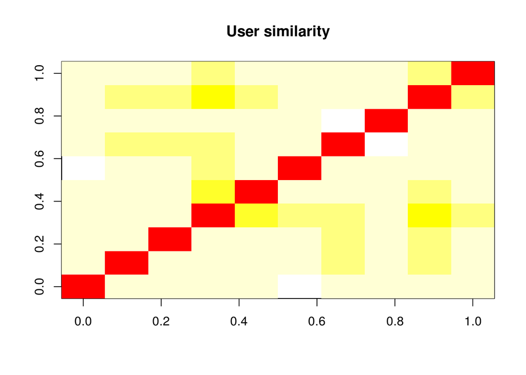

```r
image(as.matrix(similarity_users10), main = "User similarity")
```

Таким же образом можно посчитать и схожесть между фильмами. Найдите самые похожие фильмы из первых десяти:

### Предварительная подготовка данных

Сначала подготовим данные, в частности, уберем те, что являются нерелевантными.

Если фильм редкий, его мало кто видел, то оценки для него могут быть сильно смещенными. Так же и для пользователя – если он оценил малое число фильмов, то ему сложно дать рекомендацию.

Как определить, что является “малым числом”? В общем случае – итерационно, т.е. отбираем данные, строим модель, оцениваем ее и так несколько раз. В данном примере рассмотрим только один шаг – будем считать, что нас интересуют фильмы с не менее 10 оценками и пользователи, поставившие не менее 5 оценок.

Количество оценок у фильма можно посчитать с помощью функции colCounts(), а количество оценок, поставленных одним пользователем – с помощью rowCounts().

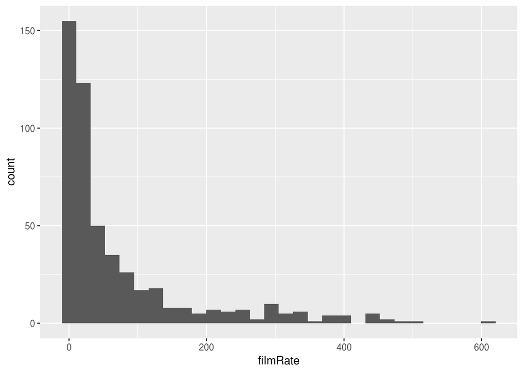

```r
ggplot(data = data.frame(filmRate=colCounts(r))) + geom_histogram(aes(x=filmRate))
```

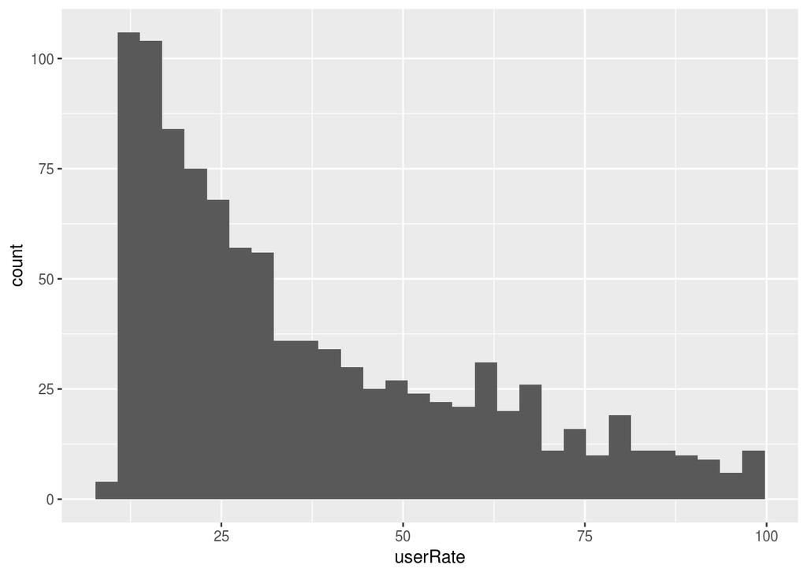

```r
ggplot(data = data.frame(userRate=rowCounts(r))) + geom_histogram(aes(x=userRate))
```

Отберем только строки и столбцы с нужным количеством оценок. Сколько фильмов осталось?

```r
ratings_movies <- r[rowCounts(r) > 5, colCounts(r) > 10]
ratings_movies
```

```
## 1000 x 352 rating matrix of class 'realRatingMatrix' with 36074 ratings.
```

Рассмотрим распределение средних оценок пользователя

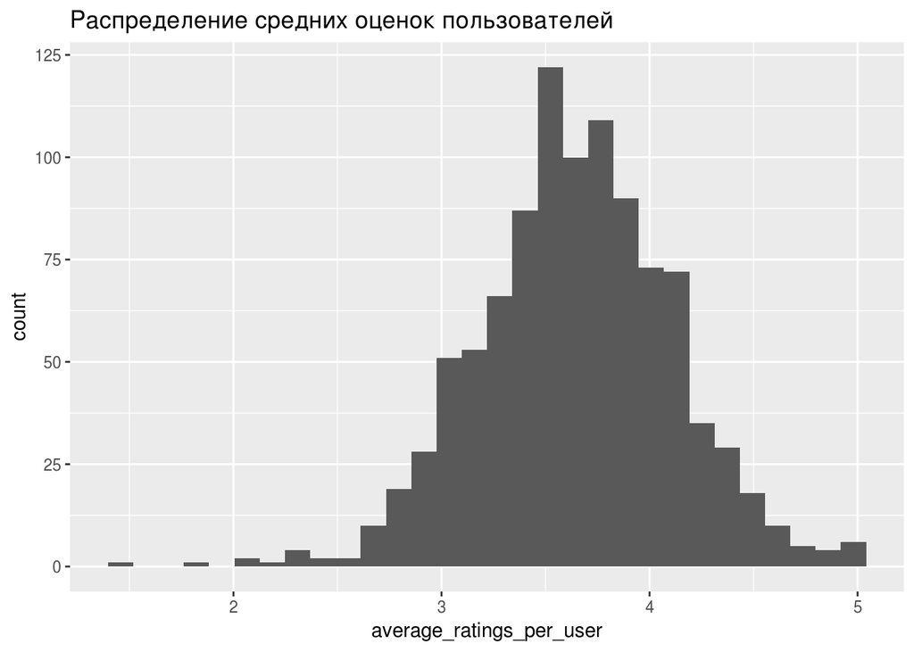

```r
average_ratings_per_user <- rowMeans(ratings_movies)
ggplot()+geom_histogram(aes(x=average_ratings_per_user)) +
ggtitle("Распределение средних оценок пользователей")
```

### Метод коллаборативной фильтрации

- вычислить похожесть всех пар фильмов
- для каждого фильма найти k наиболее похожих
- для каждого пользователя определить фильмы, наиболее близкие к тем, которые он оценил

Разделим данные на тестовую и обучающую выборки. На обучающей построим модель, для пользователей из тестовой будем рекомендовать фильмы.

```r
set.seed(100)
test_ind <- sample(1:nrow(ratings_movies), size = nrow(ratings_movies)*0.2)
recc_data_train <- ratings_movies[-test_ind, ]
recc_data_test <- ratings_movies[test_ind, ]
```

Возможны разные методы построения модели. Рассмотрим метод IBCF (“Recommender based on item-based collaborative filtering (real data).”)

Построим рекомендательную модель

```r
recc_model <- Recommender(data = recc_data_train, method = "IBCF", parameter = list(k = 30))
recc_model
```

```
## Recommender of type 'IBCF' for 'realRatingMatrix'
## learned using 800 users.
```

Детали этой модели можно получить с помощью метода getModel(), например, матрицу схожести

```r
model_details <- getModel(recc_model)
model_details$description
```

```
## [1] "IBCF: Reduced similarity matrix"
```

```r
model_details$sim[1:10, 1:10]
```

```
## 10 x 10 sparse Matrix of class "dgCMatrix"
```

```
##    [[ suppressing 10 column names '30', '77', '118' ... ]]
```

```
##
## 30  . . . . . 0.6104215 . . . .
## 77  . . . . . .         . . . .
## 118 . . . . . .         . . . .
## 143 . . . . . .         . . . .
## 148 . . . . . .         . . 1 .
## 166 . . . . . .         . . . .
## 167 . . . . . .         . . . .
## 175 . . . . . 0.7950021 1 . . .
## 187 . . . . . .         . . . .
## 199 . . . . . .         . . . .
```

Рекомендации

- для каждого пользователя извлекаются те фильмы, которые он оценил
- для каждого из фильмов находятся похожие фильмы
- затем фильмы упорядочиваются согласно весам, где вес каждой рекомендации (фильма) вычисляется на основе оценок пользователя и показателей схожести фильмов (взвешенная сумма)

```r
recc_predicted <- predict(object = recc_model, newdata = recc_data_test, n = 6)
recc_predicted
```

```
## Recommendations as 'topNList' with n = 6 for 200 users.
```

Посмотрим на результат

```r
str(recc_predicted)
```

```
## Formal class 'topNList' [package "recommenderlab"] with 4 slots
##   ..@ items     :List of 200
##   .. ..$ 846023 : int [1:6] 1 4 7 9 12 16
##   .. ..$ 720410 : int [1:6] 1 2 6 8 9 10
##   .. ..$ 1523338: int [1:6] 59 133 243 285 117 149
##   .. ..$ 139122 : int [1:6] 130 151 167 11 24 27
##   .. ..$ 1245774: int [1:6] 17 23 26 27 34 35
##   .. ..$ 1283798: int [1:6] 20 108 183 185 211 220
##   .. ..$ 2194564: int [1:6] 72 78 116 147 205 210
##   .. ..$ 972089 : int [1:6] 192 326 78 117 195 235
##   .. ..$ 1483316: int [1:6] 315 1 126 154 205 250
##   .. ..$ 477111 : int [1:6] 11 14 16 27 34 35
##   .. ..$ 1688478: int [1:6] 237 326 328 90 138 145
##   .. ..$ 2361274: int [1:6] 34 51 93 117 140 161
##   .. ..$ 780155 : int [1:6] 52 63 78 94 99 117
##   .. ..$ 1041609: int [1:6] 30 57 79 126 139 149
##   .. ..$ 2024338: int [1:6] 6 11 49 57 65 69
##   .. ..$ 1799934: int [1:6] 6 11 12 17 31 32
##   .. ..$ 565175 : int [1:6] 49 123 54 302 3 21
##   .. ..$ 944051 : int [1:6] 2 7 8 9 10 14
##   .. ..$ 947218 : int [1:6] 24 34 51 62 70 87
##   .. ..$ 1852563: int [1:6] 3 4 20 22 29 31
##   .. ..$ 1428802: int [1:6] 44 217 319 34 286 48
##   .. ..$ 1897621: int [1:6] 29 103 227 237 289 111
##   .. ..$ 1433676: int [1:6] 11 51 70 121 138 141
##   .. ..$ 1981715: int(0)
##   .. ..$ 1070158: int [1:6] 13 30 32 49 58 59
##   .. ..$ 471516 : int [1:6] 14 26 91 208 237 320
##   .. ..$ 2023419: int [1:6] 167 259 294 311 57 123
##   .. ..$ 2340736: int [1:6] 28 76 85 88 95 98
##   .. ..$ 1450163: int [1:6] 57 63 64 75 78 161
##   .. ..$ 751035 : int [1:6] 64 166 198 97 263 192
##   .. ..$ 1271916: int [1:6] 2 9 10 77 78 96
##   .. ..$ 2412043: int [1:6] 52 57 117 139 140 161
##   .. ..$ 922107 : int [1:6] 50 52 78 138 271 272
##   .. ..$ 2481937: int [1:6] 6 15 22 24 25 29
##   .. ..$ 1830361: int [1:6] 9 40 60 79 116 117
##   .. ..$ 2591448: int [1:6] 20 21 39 42 53 58
##   .. ..$ 499811 : int [1:6] 126 145 22 25 29 38
##   .. ..$ 1658355: int [1:6] 6 11 15 20 21 22
```

[output cut: 150 more lines]

```
##   .. ..$ 632025 : num [1:6] 5 5 5 5 5 5
##   .. ..$ 771105 : num [1:6] 5 5 5 5 5 5
##   .. ..$ 1822582: num [1:6] 5 5 4 4 4 4
##   .. ..$ 2246894: num [1:6] 4 4 4 4 4 4
##   .. ..$ 538456 : num [1:6] 5 5 5 5 5 5
##   .. ..$ 885900 : num [1:6] 5 5 5 5 5 5
##   .. ..$ 1064949: num [1:6] 5 5 5 5 4.5 4.5
##   .. ..$ 2237068: num [1:6] 5 5 5 5 5 5
##   .. ..$ 946716 : num [1:6] 5 5 5 5 4.5 4.5
##   .. ..$ 1250584: num [1:6] 5 5 5 5 5 5
##   .. ..$ 340405 : num [1:6] 5 5 5 4 4 4
##   .. ..$ 62968  : num [1:6] 5 5 4.67 4.5 4.5 ...
##   .. .. [list output truncated]
##   ..@ itemLabels: chr [1:352] "30" "77" "118" "143" ...
##   ..@ n         : int 6
```

Слоты (доступ через символ @)

- items – содержит индексы рекомендованных фильмов для каждого пользователя
- itemLabels – названия фильмов
- ratings – рейтинги рекомендаций
- n – число рекомендаций

Рекомендации для первого пользователя

```r
recc_user_1 <- recc_predicted@items[[1]]
recc_user_1
```

```
## [1]  1  4  7  9 12 16
```

Это результат в виде номер строк в матрице, вытащим id фильмов

```r
movies_user_1 <- recc_predicted@itemLabels[recc_user_1]
movies_user_1
```

```
## [1] "30"  "143" "167" "187" "216" "257"
```

А теперь посмотрим на названия. Функция `match` возвращает позицию, на которой элементы из первого параметра встретились во втором (см. `?match`)

Например

```r
match(c(1,5,3,2,8,1), 1:10)
```

```
## [1] 1 5 3 2 8 1
```

```r
match(c("r","a","s","c","d"), letters)
```

```
## [1] 18  1 19  3  4
```

Для названий фильмов

```r
names_movies_user_1 <- ratings$title[match(movies_user_1, ratings$movie_id)]
names_movies_user_1
```

```
## [1] Something's Gotta Give The Game               The Chorus
## [4] Death to Smoochy       Impostor               Charlotte's Web
## 507 Levels: 10 Things I Hate About You ... Wonderland
```

Посмотрим на предсказанные рейтинги. Например, для пользователя с id=1097436. Что Вы можете сказать о лучших рекомендованных ему фильмах?

```r
recc_predicted@ratings["1097436"]
```

```
## $`1097436`
## [1] 4.0 4.0 4.0 3.5 3.5 3.5
```

**Ваша очередь:**

Постройте рекомендательную систему на основе схожести между пользователями, а не между фильмами (метод UBCF вместо IBCF). Сравните для какого-нибудь пользователя результаты рекомендации

**Задание на следующий этап:**

- Анализ сети жанров/стран/производителей/… на основе совместного участия в производстве фильмов. Кластеризация и интерпретация полученных групп.
- Дополнительно: посчитать ассортативность, если имеет смысл. Например, для производителя добавить атрибутом — страну
- Построить рекомендательную систему
- Анализ датасета с привлечением дополнительных данных, найденных самостоятельно